# Regression Model of the ‘mtcars’ data

Julian Jang

November 19th, 2015

### Summary

This analysis was performed for the ‘mtcars’ dataset. By looking at a data set of a collection of cars, I was interested in exploring the relationship between a set of variables and MPG(miles per gallon) as outcome. I was particularly interested to explore.

- ‘Is an automatic or manual transmission better for MPG’
- ‘Quantify the MPG difference between automatic and manual transmissions’

In order to figure out the answers of these questions, I have performed exploratory data analysis, and used hypothesis test and linear regression as methodologies to make inference.

### Explanations of variables

At first, I have looked the meaning of ‘mtcars’ dataset variables over help pages by the command ‘?mtcars’. The meanings of the variables are below.

| column No. | Variable Name | Explanation |
| --- | --- | --- |
| [, 1] | mpg | Miles/(US) gallon |
| [, 2] | cyl | Number of cylinders |
| [, 3] | disp | Displacement (cu.in.) |
| [, 4] | hp | Gross horsepower |
| [, 5] | drat | Rear axle ratio |
| [, 6] | wt | Weight (lb/1000) |
| [, 7] | qsec | 1/4 mile time |
| [, 8] | vs | V/S |
| [, 9] | am | Transmission (0 = automatic, 1 = manual) |
| [,10] | gear | Number of forward gears |
| [,11] | carb | Number of carburetors |

I found out that ‘mpg’ might be used as the response variable and the ‘am(transmission)’ is the factor variable.

### EDA for ‘mtcars’ dataset.

I’ve started the analysis by performing initial exploratory data analysis(EDA) to get a better idea of the existing patterns between variables in the data set. Below is that I created pairwise scatter plots. This is a nice way to investigate the relationship between all the variables in this data set. And, I also created histograms of ‘mpg’ according to am type.

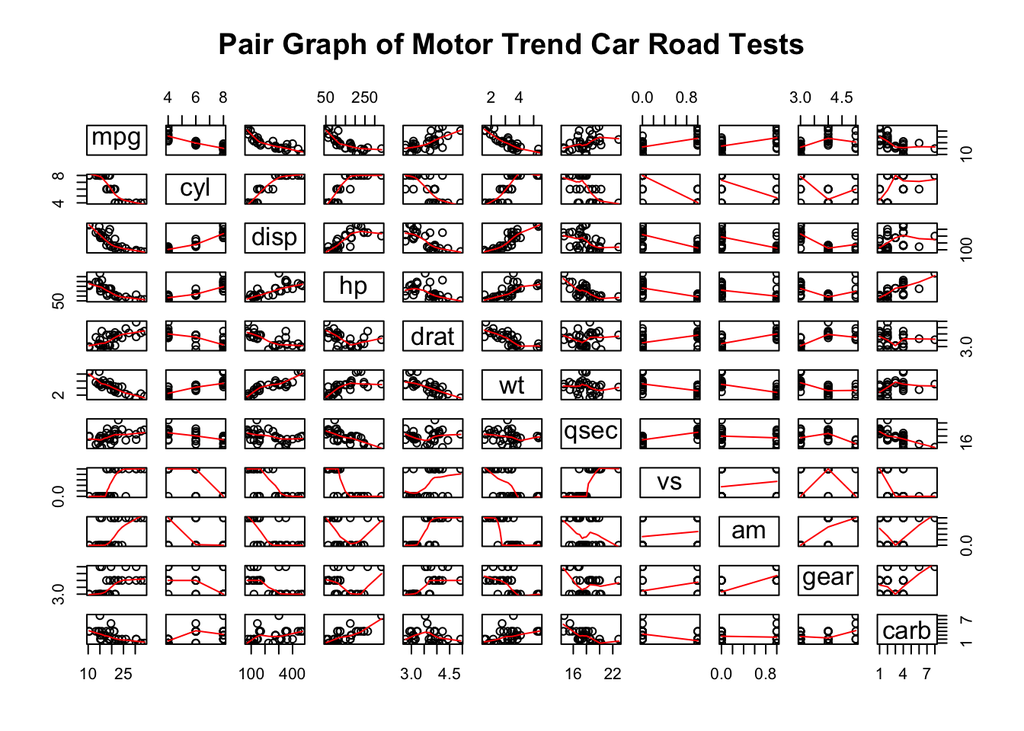

```r
pairs(mtcars, panel = panel.smooth, main="Pair Graph of Motor Trend Car Road Tests")
```

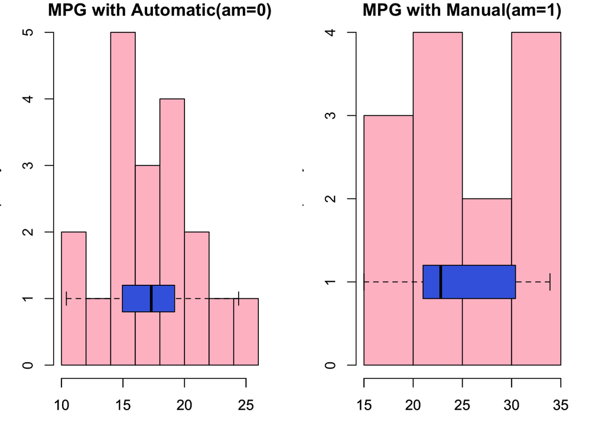

```r
par(mfrow = c(1, 2), mar=c(3.1, 3.1, 1.1, 2.1))
hist(mtcars$mpg[mtcars$am == 0], col = "pink", main = "MPG with Automatic(am=0)")
boxplot(mtcars$mpg[mtcars$am == 0], horizontal=T,  outline=T, frame=F, col = "royalblue", add = T)
hist(mtcars$mpg[mtcars$am == 1], col = "pink", main = "MPG with Manual(am=1)")
boxplot(mtcars$mpg[mtcars$am == 1], horizontal=T,  outline=T, frame=F, col = "royalblue", add = T)
```

Also, I have compared the average of ‘mpg’ between ‘Automatic’ and ‘Manual’. The result of it showed me They have difference of average. So, I needed to analyze by t.test.

```r
with(mtcars, tapply(mpg, am, mean))
```

```
##        0        1
## 17.14737 24.39231
```